# Using Buy-Till-You-Die (BTYD) Models the Online Retail Dataset

# 1 Load Data

We first want to load our datasets and perform some basic manipulation similar to those done for the association rules mining.

```r
tnx_data_tbl <- read_rds("data/retail_data_cleaned_tbl.rds")
tnx_data_tbl %>% glimpse()
```

```
## Rows: 1,044,848
## Columns: 23
## $ row_id            <chr> "ROW0000001", "ROW0000002", "ROW0000003", "ROW000000…
## $ excel_sheet       <chr> "Year 2009-2010", "Year 2009-2010", "Year 2009-2010"…
## $ invoice_id        <chr> "489434", "489434", "489434", "489434", "489434", "4…
## $ stock_code        <chr> "85048", "79323P", "79323W", "22041", "21232", "2206…
## $ description       <chr> "15CM CHRISTMAS GLASS BALL 20 LIGHTS", "PINK CHERRY …
## $ quantity          <dbl> 12, 12, 12, 48, 24, 24, 24, 10, 12, 12, 24, 12, 10, …
## $ invoice_date      <date> 2009-12-01, 2009-12-01, 2009-12-01, 2009-12-01, 200…
## $ price             <dbl> 6.95, 6.75, 6.75, 2.10, 1.25, 1.65, 1.25, 5.95, 2.55…
## $ customer_id       <chr> "13085", "13085", "13085", "13085", "13085", "13085"…
## $ country           <chr> "United Kingdom", "United Kingdom", "United Kingdom"…
## $ stock_code_upr    <chr> "85048", "79323P", "79323W", "22041", "21232", "2206…
## $ cancellation      <lgl> FALSE, FALSE, FALSE, FALSE, FALSE, FALSE, FALSE, FAL…
## $ invoice_dttm      <dttm> 2009-12-01 07:45:00, 2009-12-01 07:45:00, 2009-12-0…
## $ invoice_month     <fct> December, December, December, December, December, De…
## $ invoice_dow       <fct> Tuesday, Tuesday, Tuesday, Tuesday, Tuesday, Tuesday…
## $ invoice_dom       <chr> "01", "01", "01", "01", "01", "01", "01", "01", "01"…
## $ invoice_hour      <chr> "07", "07", "07", "07", "07", "07", "07", "07", "07"…
## $ invoice_minute    <chr> "45", "45", "45", "45", "45", "45", "45", "45", "45"…
## $ invoice_woy       <chr> "49", "49", "49", "49", "49", "49", "49", "49", "49"…
## $ invoice_ym        <chr> "200912", "200912", "200912", "200912", "200912", "2…
## $ stock_value       <dbl> 83.40, 81.00, 81.00, 100.80, 30.00, 39.60, 30.00, 59…
## $ invoice_monthprop <dbl> 0.04347826, 0.04347826, 0.04347826, 0.04347826, 0.04…
## $ exclude           <lgl> FALSE, FALSE, FALSE, FALSE, FALSE, FALSE, FALSE, FAL…
```

```r
customer_cohort_tbl <- read_rds("data/customer_cohort_tbl.rds")
customer_cohort_tbl %>% glimpse()
```

```
## Rows: 5,852
## Columns: 5
## $ customer_id     <chr> "12346", "12347", "12348", "12349", "12350", "12351", …
## $ cohort_qtr      <chr> "2010 Q1", "2010 Q4", "2010 Q3", "2010 Q2", "2011 Q1",…
## $ cohort_ym       <chr> "2010 03", "2010 10", "2010 09", "2010 04", "2011 02",…
## $ first_tnx_date  <date> 2010-03-02, 2010-10-31, 2010-09-27, 2010-04-29, 2011-…
## $ total_tnx_count <int> 3, 8, 5, 3, 1, 1, 9, 2, 1, 2, 6, 2, 5, 10, 6, 4, 10, 2…
```

Having loaded the transaction data we also want to load the summary statistics for the spend, both by invoice and on a aggregated daily basis.

```r
daily_spend_invoice_tbl <- read_rds("data/daily_spend_invoice_tbl.rds")
daily_spend_invoice_tbl %>% glimpse()
```

```
## Rows: 36,594
## Columns: 4
## $ invoice_date  <date> 2009-12-01, 2009-12-01, 2009-12-01, 2009-12-01, 2009-12…
## $ customer_id   <chr> "12490", "12533", "12682", "12758", "12836", "12913", "1…
## $ invoice_id    <chr> "489557", "489526", "489439", "489599", "489593", "48954…
## $ invoice_spend <dbl> 531.94, 821.92, 372.30, 2454.68, 423.87, 537.96, 261.00,…
```

```r
daily_spend_tbl <- read_rds("data/daily_spend_tbl.rds")
daily_spend_tbl %>% glimpse()
```

```
## Rows: 32,878
## Columns: 4
## $ invoice_date <date> 2009-12-01, 2009-12-01, 2009-12-01, 2009-12-01, 2009-12-…
## $ customer_id  <chr> "12490", "12533", "12682", "12758", "12836", "12913", "12…
## $ total_spend  <dbl> 531.94, 821.92, 372.30, 2454.68, 423.87, 537.96, 261.00, …
## $ tnx_count    <int> 1, 1, 1, 1, 1, 1, 1, 1, 1, 2, 1, 1, 1, 1, 1, 2, 1, 1, 1, …
```

Finally, we want to set a date to make the end of the “fitting” data, which will be used in the various estimation routines to fit parameters of our models.

```r
training_data_date <- as.Date("2011-03-31")
```

# 2 Background Theory

Before we start working on fitting and using the various Buy-Till-You-Die models, we first need to discuss the basic underlying theory and model.

In this model, we assume a customer becomes ‘alive’ to the business at the first purchase and then makes purchases stochastically but at a steady-rate for a period of time, and then ‘dies’ - i.e. becomes inactive to the business - hence the use of “Buy-Till-You-Die”.

Thus, at a high level these models decompose into modelling the transaction events using distributions such as the Poisson or Negative Binomial, and then modelling the ‘dropout’ process using some other method.

A number of BTYD models exist and for this workshop we will focus on the BG/NBD model - the Beta-Geometric Negative Binomial Distribution model (though we will discuss the P/NBD model also).

These models require only two pieces of information about each customer’s purchasing history: the “recency” (when the last transaction occurred) and “frequency” (the count of transactions made by that customer in a specified time period).

The notation used to represent this information is

$$X = (x, t_x, T),$$
where $x$ is the number of transactions observed in the time period $T$ and $t_x$ was the time of the last transaction.

From this summary data we can fit most BTYD models.

## 2.1 BTYD Visualisations

Despite our extensive exploration of the data earlier, the concepts around BTYD modelling suggest a few more than are worth exploring, so we will look at those now.

To start with, it might be worth understanding a bit more about when customers are ‘born’ in the system - that is, the date on which they make their first purchase. Another important quantity is the time between transactions for a customer, we we will visualise these.

```r
customer_cohort_tbl <- daily_spend_tbl %>%
  group_by(customer_id) %>%
  summarise(
    .groups = "drop",

    first_tnx_date  = min(invoice_date),
    total_tnx_count = n()
    ) %>%
  mutate(
    cohort_qtr = first_tnx_date %>% as.yearqtr(),
    cohort_ym  = first_tnx_date %>% format("%Y %m"),

    .after = "customer_id"
    )


customer_cohort_tbl %>% glimpse()
```

```
## Rows: 5,852
## Columns: 5
## $ customer_id     <chr> "12346", "12347", "12348", "12349", "12350", "12351", …
## $ cohort_qtr      <yearqtr> 2010 Q1, 2010 Q4, 2010 Q3, 2010 Q2, 2011 Q1, 2010 …
## $ cohort_ym       <chr> "2010 03", "2010 10", "2010 09", "2010 04", "2011 02",…
## $ first_tnx_date  <date> 2010-03-02, 2010-10-31, 2010-09-27, 2010-04-29, 2011-…
## $ total_tnx_count <int> 3, 8, 5, 3, 1, 1, 9, 2, 1, 2, 6, 2, 5, 10, 6, 4, 10, 2…
```

Now that we have a first date for each customer, we look at the total number of customers joining at each date.

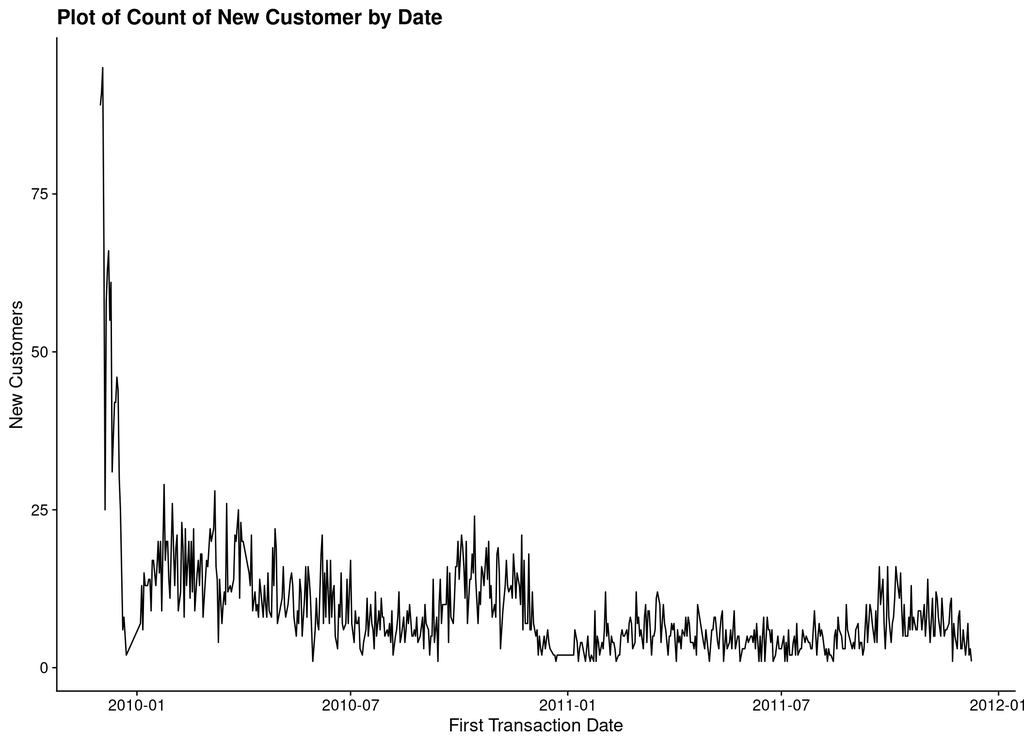

```r
plot_tbl <- customer_cohort_tbl %>%
  count(first_tnx_date, name = "n_customer")

ggplot(plot_tbl) +
  geom_line(aes(x = first_tnx_date, y = n_customer)) +
  labs(
    x = "First Transaction Date",
    y = "New Customers",
    title = "Plot of Count of New Customer by Date"
    )
```

We know look at how time differences between purchases are distributed.

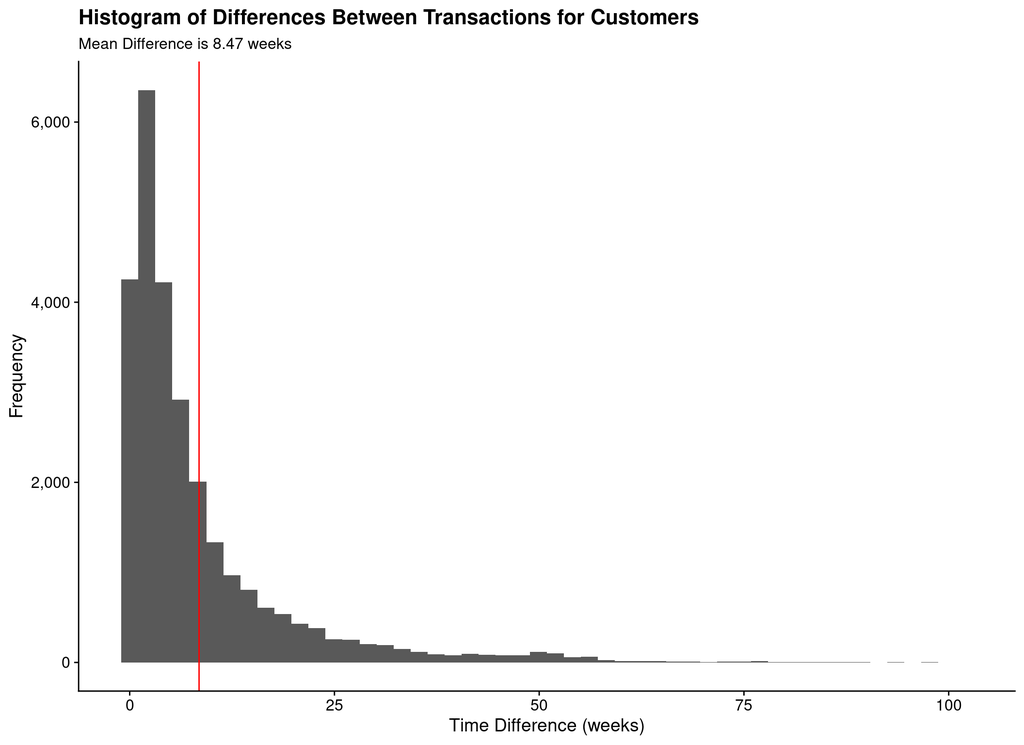

```r
customer_tnx_diffs_tbl <- daily_spend_tbl %>%
  group_by(customer_id) %>%
  summarise(
    .groups = "drop",

    time_diff = diff(invoice_date) %>% as.numeric() %>% divide_by(7)
  )

mean_diff <- customer_tnx_diffs_tbl %>% pull(time_diff) %>% mean()

ggplot(customer_tnx_diffs_tbl) +
  geom_histogram(aes(x = time_diff), bins = 50) +
  geom_vline(aes(xintercept = mean_diff), colour = "red") +
  scale_y_continuous(labels = label_comma()) +
  labs(
    x = "Time Difference (weeks)",
    y = "Frequency",
    title = "Histogram of Differences Between Transactions for Customers",
    subtitle = glue(
      "Mean Difference is {mean_diff} weeks", mean_diff = mean_diff %>% round(2)
      )
    )
```

We also want to look at a number of customers and make some line plots of their transactions.

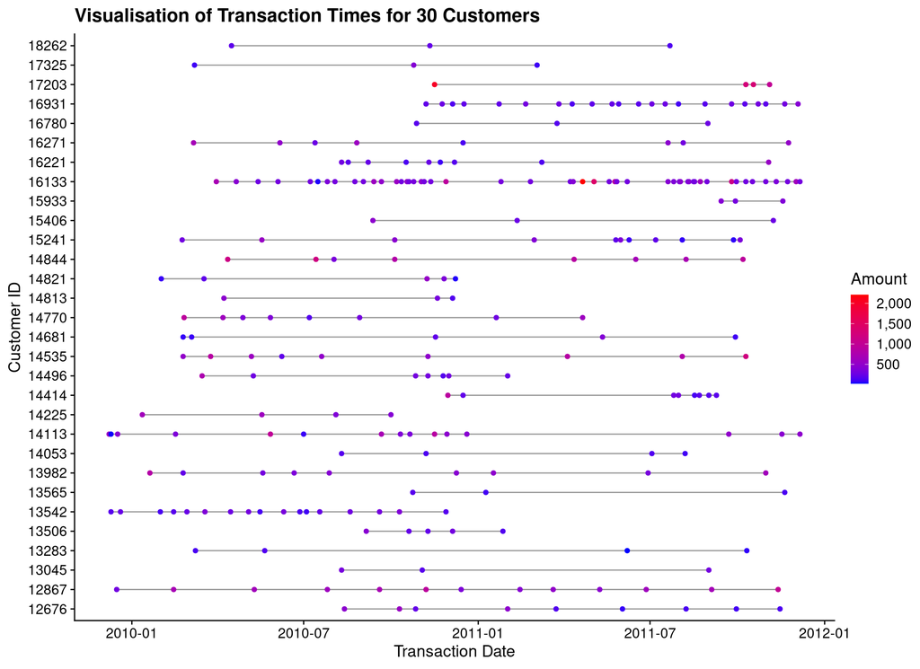

```r
keep_customers_tbl <- customer_cohort_tbl %>%
  filter(total_tnx_count > 2) %>%
  slice_sample(n = 30)

plot_tbl <- daily_spend_tbl %>%
  semi_join(keep_customers_tbl, by = "customer_id")

ggplot(plot_tbl, aes(x = invoice_date, y = customer_id, group = customer_id)) +
  geom_line(alpha = 0.4) +
  geom_point(aes(colour = total_spend)) +
  scale_colour_gradient(low = "blue", high = "red", label = label_comma()) +
  labs(
    x = "Transaction Date",
    y = "Customer ID",
    colour = "Amount",
    title = "Visualisation of Transaction Times for 30 Customers"
    ) +
  theme(axis.text.y = element_text(size = 12))
```

## 2.2 BTYD Models

There are a number of different statistical approaches to building BTYD models - relying on a number of different assumptions about how the various recency, frequency and monetary values are modelled.

We now discuss a number of different ways of modelling this.

### 2.2.1 Beta-Geometric/Negative-Binomial Distribution (BG/NBD) Model

This model relies on a number of base assumptions:

1. While active, the number of transactions made by a customer follows a Poisson process with transaction rate $\lambda$.
2. Heterogeneity in $\lambda$ follows a Gamma distribution $\Gamma(\lambda \, | \, \alpha, r)$ with parameters shape $r$ and rate $\alpha$.
3. After any transaction, a customer becomes inactive with probability $p$.
4. Heterogeneity in $p$ follows a Beta distribution $B(p \, | \, a, b)$ with shape parameters $a$ and $b$.
5. The transaction rate $\lambda$ and the dropout probability $p$ vary independently across customers.

Note that it follows from the above assumptions that the probability of a customer being ‘alive’ after any transaction is given by the Geometric distribution, and hence the Beta-Geometric in the name.

To put this into more formal mathematical notation, we have:

$$\begin{eqnarray*}
\lambda &\sim& \Gamma(\alpha, r) \\
P(\text{alive}, k) &\sim& \text{Geometric}(p, k) \\
p &\sim& \text{Beta}(a, b)
\end{eqnarray*}$$

### 2.2.2 Pareto/Negative-Binomial Distribution (P/NBD) Model

Similar to the BG/NBD model, the P/NBD model relies on five assumptions:

1. While active, the number of transactions made by a customer follows a Poisson process with transaction rate $\lambda$.
2. Heterogeneity in $\lambda$ follows a Gamma distribution $\Gamma(\lambda \, | \, \alpha, r)$ with shape $r$ and rate $\alpha$.
3. Each customer has an unobserved ‘lifetime’ of length $\tau$. This point at which the customer becomes inactive is distributed as an exponential with dropout rate $\mu$.
4. Heterogeneity in dropout rates across customers follows a Gamma distribution $\Gamma(\mu \, | \, s, \beta)$ with shape parameter $s$ and rate parameter $\beta$.
5. The transaction rate $\lambda$ and the dropout rate $\mu$ vary independently across customers.

As before, we express this in mathematical notation as:

$$\begin{eqnarray*}
\lambda &\sim& \Gamma(\alpha, r) \\
\mu &\sim& \Gamma(s, \beta) \\
\tau &\sim& \text{Exponential}(\mu)
\end{eqnarray*}$$

### 2.2.3 Gamma/Gamma Spending Model

The final piece of this approach is to construct a spending model for the transactions. Similar to transaction rates, spending patterns are often skewed, so a Gamma distribution is used.

For the Gamma/Gamma model, we use the following assumptions:

In mathematical notation, we have:

## 2.3 Investigate Cohorts

Finally, we want to take a look at the distribution of transaction times based on various first-transaction cohorts in the data.

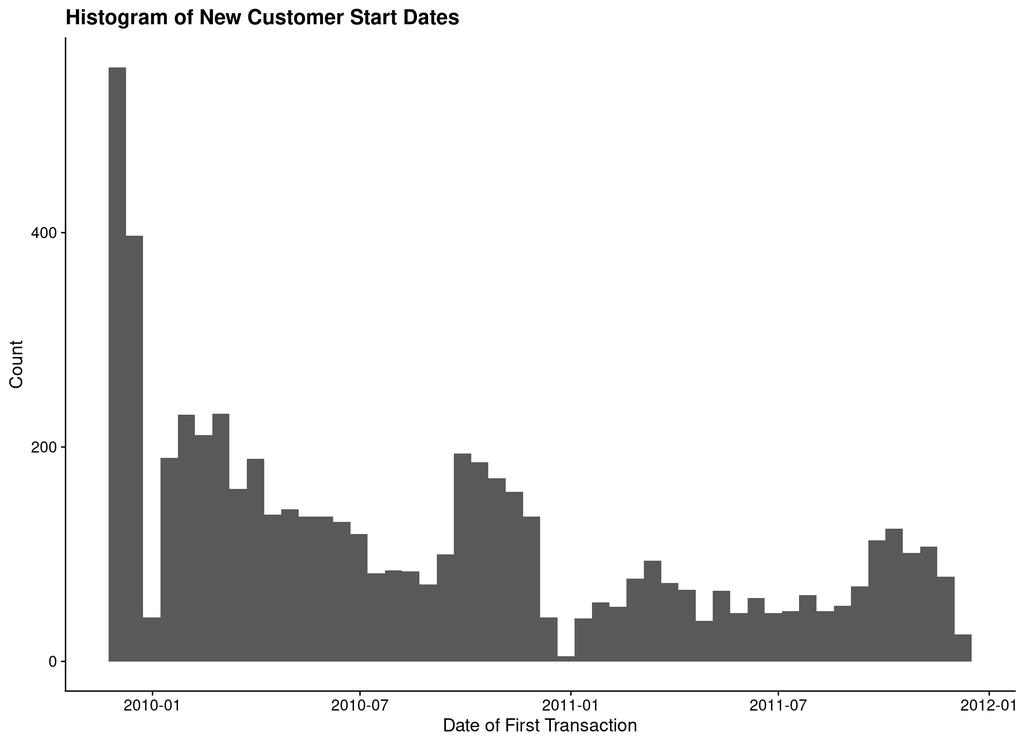

```r
ggplot(customer_cohort_tbl) +
  geom_histogram(aes(x = first_tnx_date), bins = 50) +
  labs(
    x = "Date of First Transaction",
    y = "Count",
    title = "Histogram of New Customer Start Dates"
    )
```

We also want to get a sense of the total count of customers in each cohort.

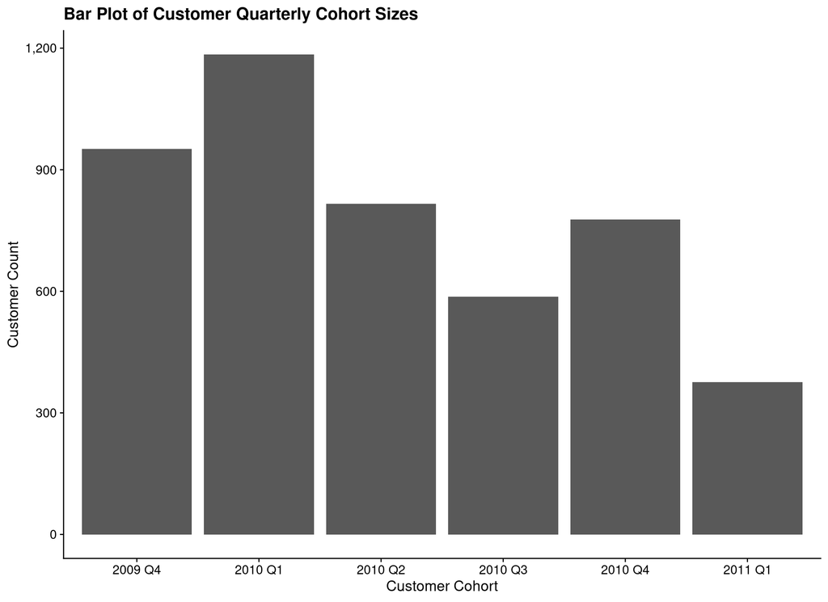

```r
plot_tbl <- customer_cohort_tbl %>%
  filter(first_tnx_date <= training_data_date) %>%
  count(cohort_qtr, name = "customer_count") %>%
  mutate(cohort_qtr = cohort_qtr %>% as.character())

ggplot(plot_tbl) +
  geom_col(aes(x = cohort_qtr, y = customer_count)) +
  scale_y_continuous(labels = label_comma()) +
  labs(
    x = "Customer Cohort",
    y = "Customer Count",
    title = "Bar Plot of Customer Quarterly Cohort Sizes"
    )
```

We also want to see the monthly cohorts:

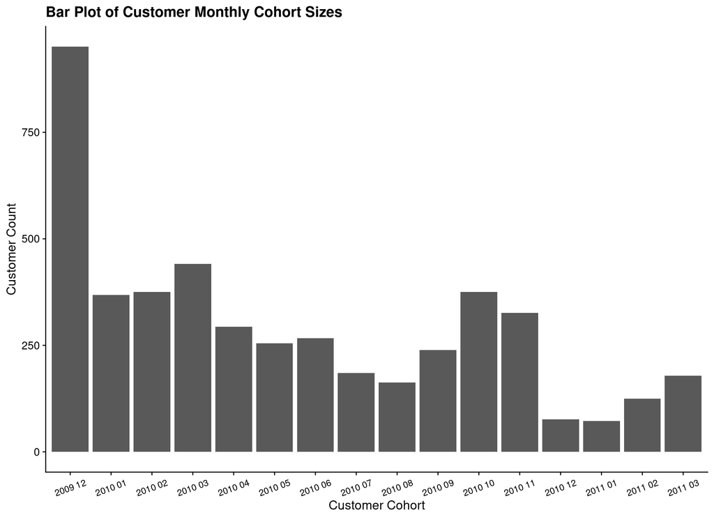

```r
plot_tbl <- customer_cohort_tbl %>%
  filter(first_tnx_date <= training_data_date) %>%
  count(cohort_ym, name = "customer_count") %>%
  mutate(cohort_ym = cohort_ym %>% as.character())

ggplot(plot_tbl) +
  geom_col(aes(x = cohort_ym, y = customer_count)) +
  scale_y_continuous(labels = label_comma()) +
  labs(
    x = "Customer Cohort",
    y = "Customer Count",
    title = "Bar Plot of Customer Monthly Cohort Sizes"
    ) +
  theme(
    axis.text.x = element_text(size = 10, angle = 20, vjust = 0.5)
    )
```

For the cohort analysis, we start with a boxplot of the time difference between transactions by cohort.

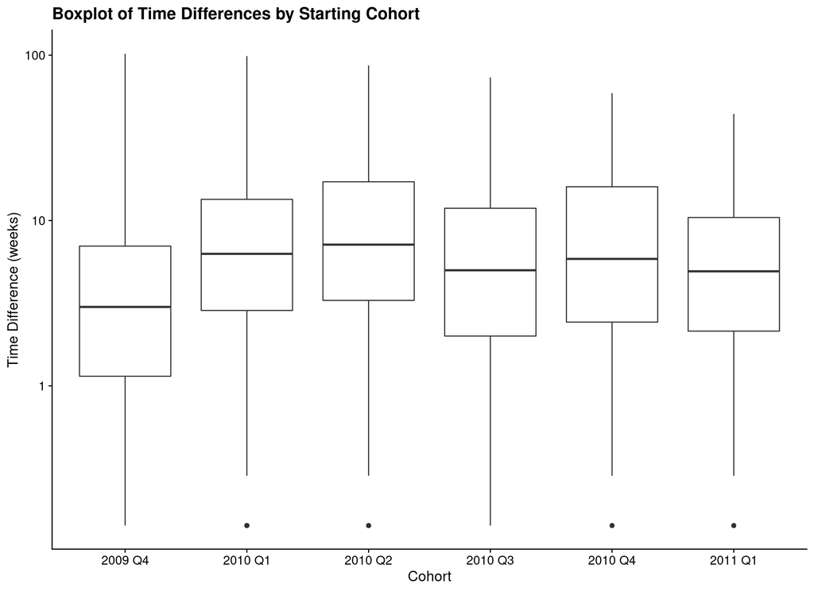

```r
plot_tbl <- customer_cohort_tbl %>%
  filter(first_tnx_date <= training_data_date) %>%
  inner_join(customer_tnx_diffs_tbl, by = "customer_id") %>%
  mutate(cohort_qtr = cohort_qtr %>% as.character())

ggplot(plot_tbl) +
  geom_boxplot(aes(x = cohort_qtr, y = time_diff)) +
  scale_y_log10() +
  labs(
    x = "Cohort",
    y = "Time Difference (weeks)",
    title = "Boxplot of Time Differences by Starting Cohort"
    )
```

We also construct a density plot of the time differences for these cohorts.

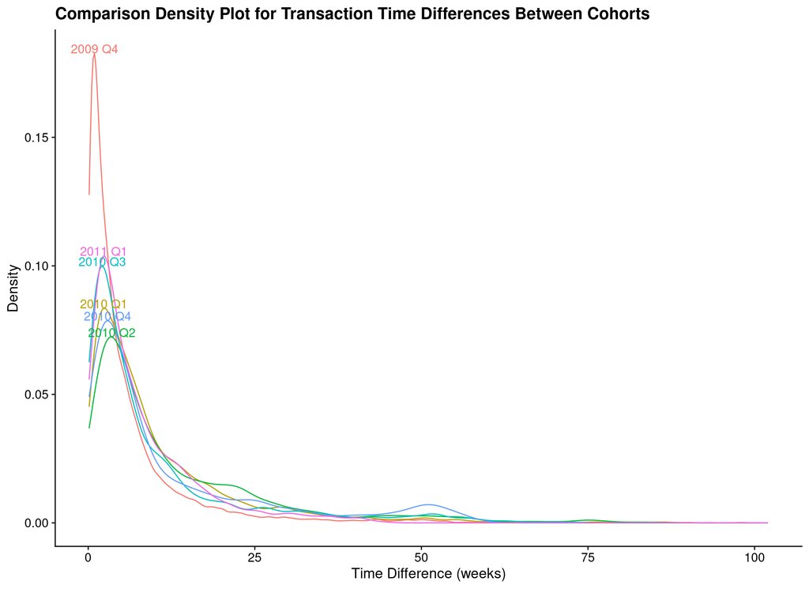

```r
ggplot(plot_tbl, aes(x = time_diff, colour = cohort_qtr)) +
  geom_line(stat = "density") +
  geom_dl(aes(label = cohort_qtr), method = "top.bumpup", stat = "density") +
  labs(
    x = "Time Difference (weeks)",
    y = "Density",
    title = "Comparison Density Plot for Transaction Time Differences Between Cohorts"
    ) +
  theme(legend.position = "none")
```

And we also look at a facetted-histogram

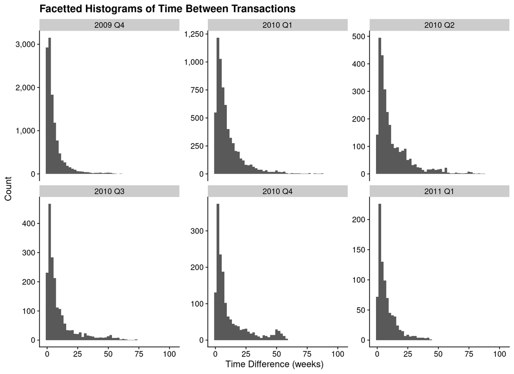

```r
ggplot(plot_tbl) +
  geom_histogram(aes(x = time_diff), bins = 50) +
  facet_wrap(vars(cohort_qtr), scales = "free_y") +
  scale_y_continuous(labels = label_comma()) +
  labs(
    x = "Time Difference (weeks)",
    y = "Count",
    title = "Facetted Histograms of Time Between Transactions"
    )
```

### 2.3.1 Investigate Dropout Rates

We want to plot some visualisations of the lifetime and dropout rate of customers in each cohort.

```r
cohort_dropout_est_tbl <- customer_cohort_tbl %>%
  select(
    customer_id, first_tnx_date, cohort_qtr, cohort_ym
    ) %>%
  filter(
    first_tnx_date <= training_data_date
    ) %>%
  inner_join(daily_spend_tbl, by = "customer_id") %>%
  group_by(cohort_qtr, customer_id) %>%
  mutate(
    final_tnx_date = max(invoice_date)
    ) %>%
  ungroup() %>%
  select(
    customer_id, cohort_qtr, first_tnx_date, final_tnx_date
    ) %>%
  distinct() %>%
  mutate(
    obs_lifetime = difftime(final_tnx_date, first_tnx_date, units = "week") %>%
      as.numeric()
    ) %>%
  filter(obs_lifetime > 0) %>%
  group_by(cohort_qtr) %>%
  summarise(
    .groups = "drop",

    lifetimes = list(obs_lifetime)
    )

cohort_dropout_est_tbl %>% glimpse()
```

```
## Rows: 6
## Columns: 2
## $ cohort_qtr <yearqtr> 2009 Q4, 2010 Q1, 2010 Q2, 2010 Q3, 2010 Q4, 2011 Q1
## $ lifetimes  <list> <104.2857143, 96.7142857, 104.2857143, 89.4285714, 94.0…
```

# 3 Create Initial BTYD Model

We want to start building and investigating our initial BTYD models and there are two main packages we will use for this process: `BTYD` and `CLVTools`.

## 3.1 First BTYD Model

We start using the `BTYD` package, using the various functions provided.

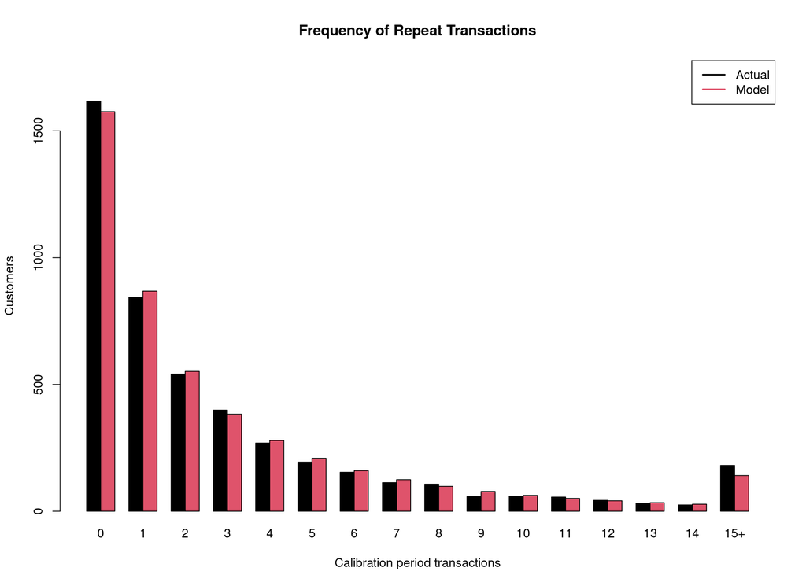

```r
daily_cbscbt <- daily_spend_tbl %>%
  select(cust = customer_id, date = invoice_date, sales = total_spend) %>%
  dc.ElogToCbsCbt(
    per             = "week",
    T.cal           = training_data_date,
    merge.same.date = TRUE
    )

params_btyd_bgnbd <- daily_cbscbt$cal$cbs %>%
  bgnbd.EstimateParameters()


bgnbd_tnxfreq <- bgnbd.PlotFrequencyInCalibration(
  params  = params_btyd_bgnbd,
  cal.cbs = daily_cbscbt$cal$cbs,
  censor  = 15
  )
```

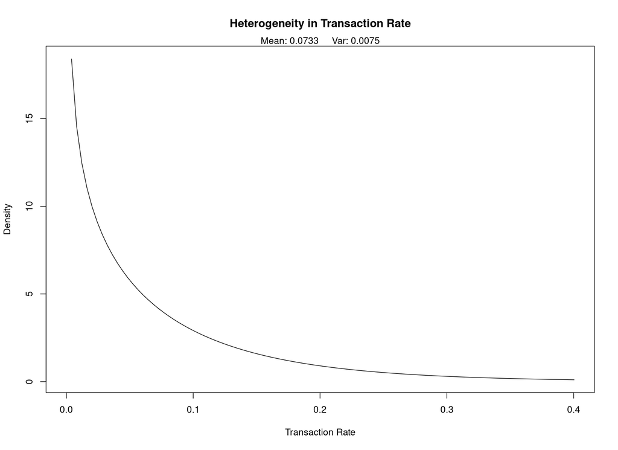

```r
bgnbd_tnxrate  <- bgnbd.PlotTransactionRateHeterogeneity(params = params_btyd_bgnbd)
```

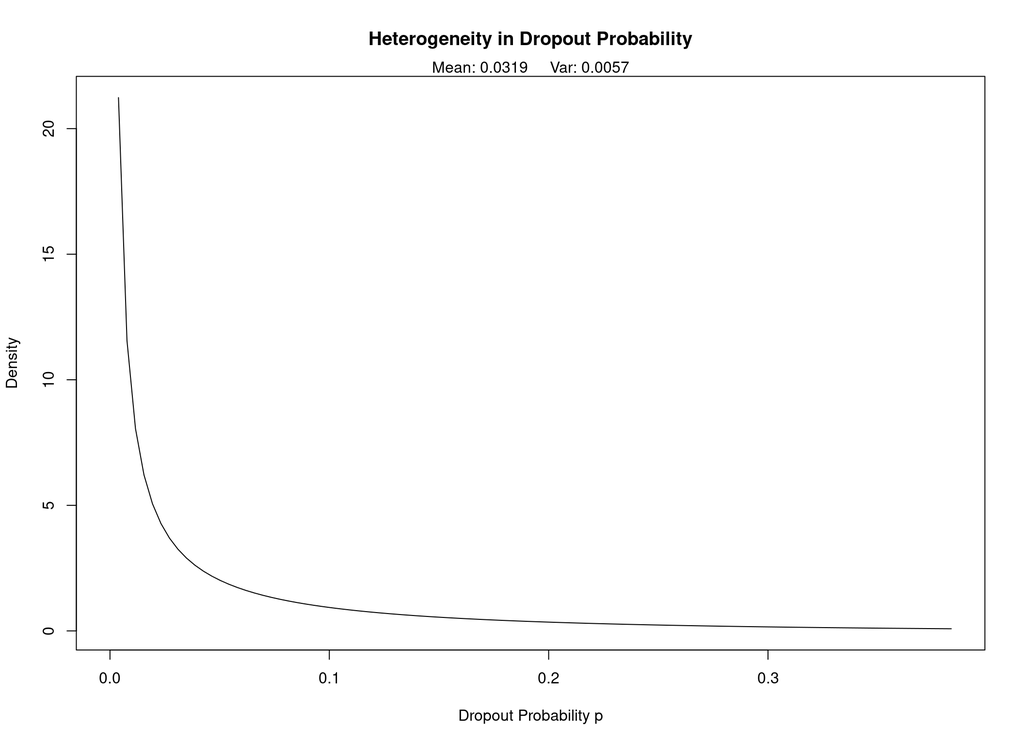

```r
bgnbd_droprate <- bgnbd.PlotDropoutRateHeterogeneity    (params = params_btyd_bgnbd)
```

```r
bgnbd.Expectation(params = params_btyd_bgnbd, t = 52)
```

```
##       p3
## 3.495892
```

```r
bgnbd.PAlive(params = params_btyd_bgnbd, x = 5, t.x = 26, T.cal = 30)
```

```
##        p3
## 0.9697112
```

## 3.2 First CLVTools Model

We also want to fit an equivalent model in `CLVTools` but this requires a bit more work upfront as it requires you to explicitly remove new customers in the data.

```r
customer_fitdata_tbl <- customer_cohort_tbl %>%
  select(customer_id, first_tnx_date, cohort_qtr, cohort_ym) %>%
  filter(first_tnx_date <= training_data_date) %>%
  inner_join(daily_spend_tbl, by = "customer_id")

customer_fitdata_tbl %>% glimpse()
```

```
## Rows: 30,324
## Columns: 7
## $ customer_id    <chr> "12346", "12346", "12346", "12347", "12347", "12347", "…
## $ first_tnx_date <date> 2010-03-02, 2010-03-02, 2010-03-02, 2010-10-31, 2010-1…
## $ cohort_qtr     <yearqtr> 2010 Q1, 2010 Q1, 2010 Q1, 2010 Q4, 2010 Q4, 2010 Q…
## $ cohort_ym      <chr> "2010 03", "2010 03", "2010 03", "2010 10", "2010 10", …
## $ invoice_date   <date> 2010-03-02, 2010-06-28, 2011-01-18, 2010-10-31, 2010-1…
## $ total_spend    <dbl> 27.05, 142.31, 77183.60, 611.53, 711.79, 475.39, 636.25…
## $ tnx_count      <int> 1, 1, 1, 1, 1, 1, 1, 1, 1, 1, 1, 1, 1, 1, 1, 1, 1, 1, 1…
```

We now use this data to construct the `clvdata` that will be used to fit our models.

```r
customer_clvdata <- customer_fitdata_tbl %>%
  clvdata(
    date.format      = "%Y-%m-%d",
    time.unit        = "weeks",
    estimation.split = training_data_date,
    name.id          = "customer_id",
    name.date        = "invoice_date",
    name.price       = "total_spend"
    )
```

```
## CLV Transaction Data
##
## Time unit         Weeks
## Estimation length 69.2857 Weeks
## Holdout length    36.0000 Weeks
##
## Transaction Data Summary
##                                    Estimation        Holdout          Total
## Number of customers                -                 -                4691
## First Transaction in period        2009-12-01        2011-04-01       2009-12-01
## Last Transaction in period         2011-03-31        2011-12-09       2011-12-09
## Total # Transactions               20502             9822             30324
## Mean # Transactions per cust       4.370             3.662            6.464
## (SD)                               7.058             5.153            10.865
## Mean Spending per Transaction      513.282           553.777          526.398
## (SD)                               1219.322          1401.131         1281.156
## Total Spending                     10523300.574      5439194.742      1.6e+07
## Total # zero repeaters             1617              2009             1082
## Percentage # zero repeaters        0.345             0.428            0.231
## Mean Interpurchase time            12.082            8.963            17.344
## (SD)                               9.937             6.343            15.079
```

We now want to fit the BG/NBD model using this input data. Fitting these models can take a bit of trial-and-error, but we can use our knowledge of the Gamma and Beta distributions to give us starting points that seems reasonable and this should help with the fitting process.

```r
params_bgnbd_clvfit <- bgnbd(
  clv.data = customer_clvdata,
  start.params.model = c(r = 0.5, alpha = 10, a = 0.1, b = 9.9),
  verbose  = TRUE
  )

params_bgnbd_clvfit %>% summary()
```

```
## BG/NBD Standard  Model
##
## Call:
## bgnbd(clv.data = customer_clvdata, start.params.model = c(r = 0.5,
##     alpha = 10, a = 0.1, b = 9.9), verbose = TRUE)
##
## Fitting period:
## Estimation start  2009-12-01
## Estimation end    2011-03-31
## Estimation length 69.2857 Weeks
##
## Coefficients:
##       Estimate Std. Error  z-val Pr(>|z|)
## r      0.71871    0.02126 33.804  < 2e-16 ***
## alpha  9.80293    0.35622 27.520  < 2e-16 ***
## a      0.14114    0.03914  3.606 0.000311 ***
## b      4.28015    1.71915  2.490 0.012785 *
## ---
## Signif. codes:  0 '***' 0.001 '**' 0.01 '*' 0.05 '.' 0.1 ' ' 1
##
## Optimization info:
## LL     -49702.4660
## AIC    99412.9319
## BIC    99438.7455
## KKT 1  TRUE
## KKT 2  TRUE
## fevals 54.0000
## Method BFGS
```

With our fitted model, we can now use these parameters to produce predictions for the holdout period and compare it to what happened during this time - this gives us a method of validating our model and discovering where we may have issues with the model.

Before we look at predictions, we look for the output plots.

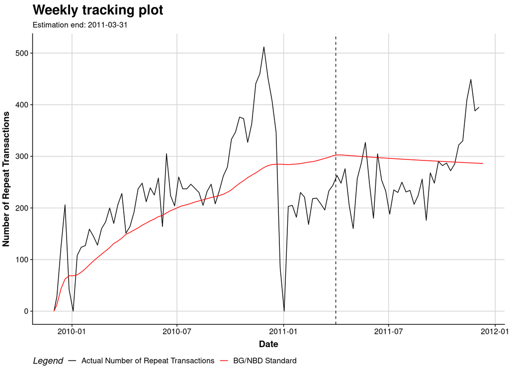

```r
params_bgnbd_clvfit %>% plot()
```

### 3.2.1 Check Model Fits

We now want to check the validity of the fit by using these parameters to generate some data and compare the outputs of this process against the data.

We first check the distribution of the transaction process. The model assumes that the transaction rates $\lambda$ are distribution according to a Gamma distribution with shape $r$ and rate $\alpha$. This suggests the average rate is $r / \alpha$.

```r
predict_rates_tbl <- params_bgnbd_clvfit %>%
  predict() %>%
  mutate(
    lambda = CET / period.length
    )

predict_rates <- predict_rates_tbl %>% pull(lambda)

predict_r     <- params_bgnbd_clvfit %>% coefficients() %>% extract("r")
predict_alpha <- params_bgnbd_clvfit %>% coefficients() %>% extract("alpha")

sim_rates <- predict_rates %>%
  length() %>%
  rgamma(shape = predict_r, rate = predict_alpha)

create_summ_table <- function(x) {
  x %>%
    summary() %>%
    enframe() %>%
    mutate(value = as.numeric(value))
}

compare_tbl <- list(
    predict = predict_rates %>% create_summ_table(),
    sim     = sim_rates     %>% create_summ_table()
    ) %>%
  bind_rows(.id = "source") %>%
  pivot_wider(
    names_from  = "name",
    values_from = "value"
    )

compare_tbl %>% glimpse()
```

```
## Rows: 2
## Columns: 7
## $ source    <chr> "predict", "sim"
## $ Min.      <dbl> 1.734980e-05, 1.291625e-06
## $ `1st Qu.` <dbl> 0.02154413, 0.01315656
## $ Median    <dbl> 0.04043844, 0.04298661
## $ Mean      <dbl> 0.06257582, 0.07286165
## $ `3rd Qu.` <dbl> 0.07012204, 0.10127992
## $ Max.      <dbl> 1.8028022, 0.9100715
```

```r
compare_tbl %>% print()
```

```
## # A tibble: 2 × 7
##   source        Min. `1st Qu.` Median   Mean `3rd Qu.`  Max.
##   <chr>        <dbl>     <dbl>  <dbl>  <dbl>     <dbl> <dbl>
## 1 predict 0.0000173     0.0215 0.0404 0.0626    0.0701 1.80
## 2 sim     0.00000129    0.0132 0.0430 0.0729    0.101  0.910
```

We can also compare these two sets of data by plotting a histogram.

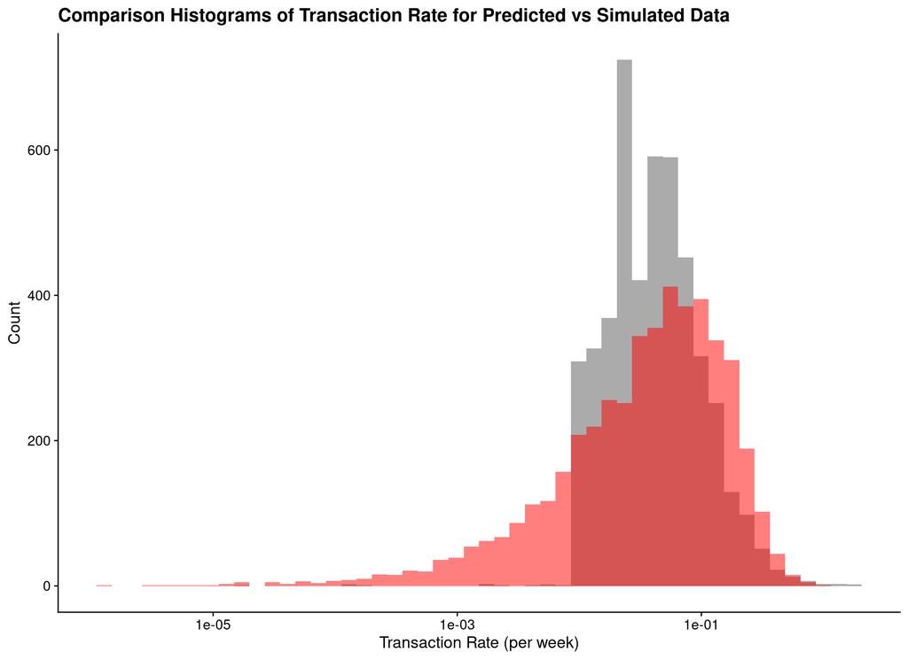

```r
ggplot() +
  geom_histogram(aes(x = predict_rates), bins = 50, alpha = 0.5) +
  geom_histogram(aes(x = sim_rates), bins = 50, alpha = 0.5, fill = "red") +
  scale_x_log10() +
  labs(
    x = "Transaction Rate (per week)",
    y = "Count",
    title = "Comparison Histograms of Transaction Rate for Predicted vs Simulated Data"
    )
```

### 3.2.2 Investigating Spending Models

Now that we have plotted this data, we want to run our prediction routines on the fitted data and look at the output.

```r
predict_bgnbd_tbl <- params_bgnbd_clvfit %>% predict()
predict_bgnbd_tbl %>% glimpse()
```

```
## Rows: 4,691
## Columns: 9
## $ Id                      <chr> "12346", "12347", "12348", "12349", "12350", "…
## $ period.first            <date> 2011-04-01, 2011-04-01, 2011-04-01, 2011-04-0…
## $ period.last             <date> 2011-12-09, 2011-12-09, 2011-12-09, 2011-12-0…
## $ period.length           <dbl> 36.14286, 36.14286, 36.14286, 36.14286, 36.142…
## $ actual.x                <int> 0, 5, 2, 1, 0, 0, 3, 1, 1, 2, 1, 2, 2, 3, 0, 9…
## $ actual.total.spending   <dbl> 0.00, 3122.82, 597.00, 1457.55, 0.00, 0.00, 74…
## $ predicted.mean.spending <dbl> 24912.7873, 528.2466, 417.1340, 760.8523, 411.…
## $ CET                     <dbl> 1.3980874, 2.8216056, 2.4735085, 0.9799995, 1.…
## $ PAlive                  <dbl> 0.9593805, 0.9361610, 0.9435850, 0.9301321, 1.…
```

The above prediction depends on constructing a Gamma-Gamma based spending model, which adds the monetary part of the model. To do this, we now plot the fitted spending distribution against the actual spend to see how well we capture the data.

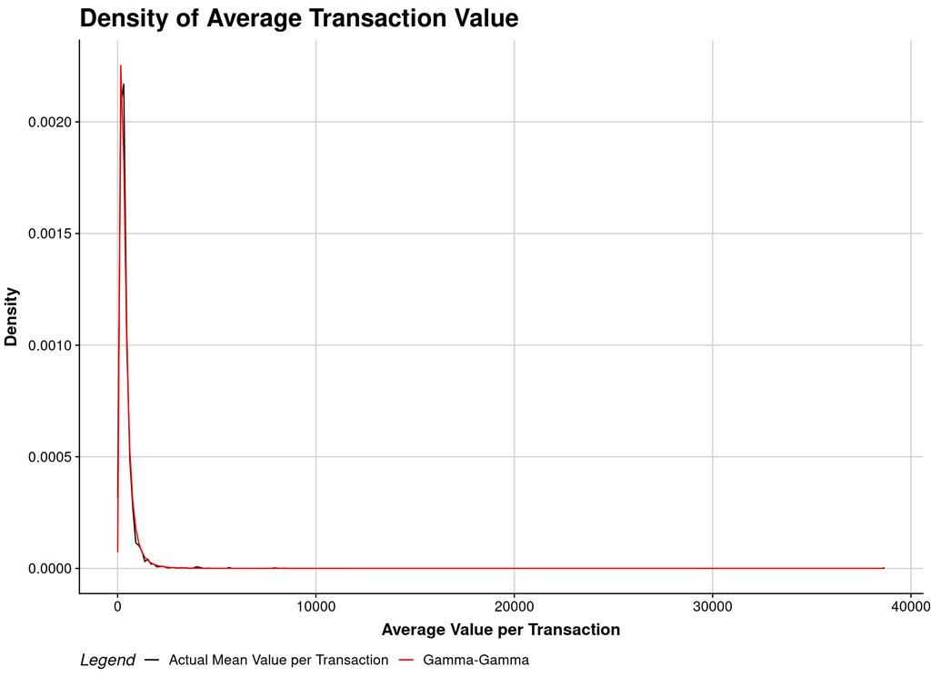

```r
customer_spending_gg <- customer_clvdata %>%
  gg(verbose = TRUE)

customer_spending_gg %>% plot()
```

We also want to check the quality of the fit for the heterogeneity of the spending patterns.

To do this, we note that it follows from above that the mean spending $\bar{x}$ is calculated from the Gamma distribution

$$\bar{x} = \frac{p}{\nu}.$$
We thus recover each individual customer $\nu$ from the mean spend by

$$\nu = \frac{p}{\bar{x}}.$$
We thus have a $\nu$ value for each customer, and then compare this empirical distribution for $\nu$ against those drawn from a Gamma distribution with the other parameters from the fit.

```r
params_customer_spending <- customer_spending_gg %>%
  coefficients()

spend_predict_tbl <- customer_spending_gg %>%
  predict() %>%
  mutate(
    nu = params_customer_spending['p'] / predicted.mean.spending
    )

predict_nu <- spend_predict_tbl %>%
  pull(nu)

sim_nu <- predict_nu %>%
  length() %>%
  rgamma(
    shape = params_customer_spending['q'],
    rate  = params_customer_spending['gamma']
    )
```

```r
nu_compare_tbl <- list(
    predict = predict_nu %>% create_summ_table(),
    sim     = sim_nu     %>% create_summ_table()
    ) %>%
  bind_rows(.id = "source") %>%
  pivot_wider(
    names_from  = "name",
    values_from = "value"
    )

nu_compare_tbl %>% glimpse()
```

```
## Rows: 2
## Columns: 7
## $ source    <chr> "predict", "sim"
## $ Min.      <dbl> 9.012305e-05, 3.099409e-04
## $ `1st Qu.` <dbl> 0.005452025, 0.004654609
## $ Median    <dbl> 0.005452025, 0.006930327
## $ Mean      <dbl> 0.006335680, 0.007602117
## $ `3rd Qu.` <dbl> 0.007368020, 0.009772662
## $ Max.      <dbl> 0.04986756, 0.02756229
```

As before, we construct a histogram of the two sets of data.

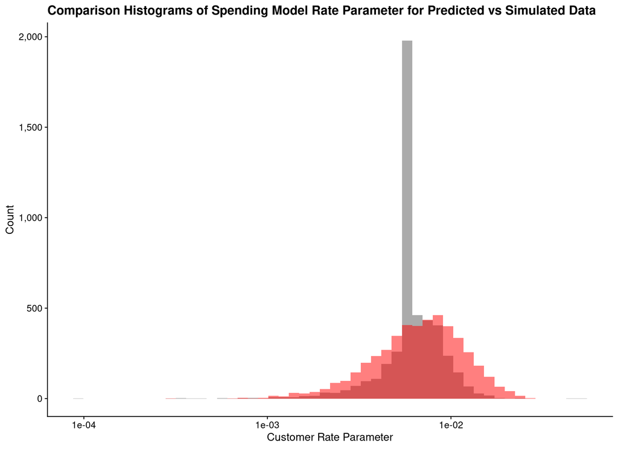

```r
ggplot() +
  geom_histogram(aes(x = predict_nu), bins = 50, alpha = 0.5) +
  geom_histogram(aes(x = sim_nu), bins = 50, alpha = 0.5, fill = "red") +
  scale_x_log10() +
  scale_y_continuous(labels = label_comma()) +
  labs(
    x = "Customer Rate Parameter",
    y = "Count",
    title = "Comparison Histograms of Spending Model Rate Parameter for Predicted vs Simulated Data"
    )
```

# 4 Additional Model Explorations

Another interesting way to think about the model fit is to break the data up into the different cohorts, fit each subset of the data separately, then plot each of the parameters of the model by cohort.

We also consider using a bootstrap approach to get an indication of the variance in the parameter estimates.

Note that the two approaches have parallels - it is a simple idea from a conceptual and implementation point of view, with the cost of additional computation since we need to fit multiple models.

```r
convert_tnxdata_clvdata <- function(tnx_data_tbl, end_date,
                                    spend_col = "total_spend") {
  customer_clvdata <- tnx_data_tbl %>%
    clvdata(
      date.format      = "%Y-%m-%d",
      time.unit        = "weeks",
      estimation.split = end_date,
      name.id          = "customer_id",
      name.date        = "invoice_date",
      name.price       = spend_col
      )

  return(customer_clvdata)
}
```

```r
extract_bgnbd_parameters <- function(fit_clvdata) {
  mean_tbl <- fit_clvdata %>%
    coefficients() %>%
    enframe(name = "parameter", value = "mean")

  sd_tbl   <- fit_clvdata %>%
    confint(level = 0.5) %>%
    as_tibble(rownames = "parameter") %>%
    rename(
      p025 = `25 %`,
      p075 = `75 %`
    )

  params_tbl <- mean_tbl %>%
    inner_join(sd_tbl, by = "parameter")

  return(params_tbl)
}
```

## 4.1 Investigate Cohort-Specific Model Fits

We now want to gather up the transaction data into the different cohorts and use that subset of the data to fit models. We then visualise the differences in the parameters using facet plots.

```r
qtr_cohort_bgnbd_tbl <- customer_fitdata_tbl %>%
  group_nest(cohort_qtr, .key = "tnx_data", keep = TRUE) %>%
  mutate(
    clv_data = map(
      tnx_data, convert_tnxdata_clvdata,
      end_date = training_data_date
      ),
    bgnbd_fit = map(
      clv_data, bgnbd,
      start.params.model = c(r = 0.5, alpha = 5, a = 0.1, b = 9.9)
      ),
    param_data = map(bgnbd_fit, extract_bgnbd_parameters)
    )

qtr_cohort_bgnbd_tbl %>% glimpse()
```

```
## Rows: 6
## Columns: 5
## $ cohort_qtr <yearqtr> 2009 Q4, 2010 Q1, 2010 Q2, 2010 Q3, 2010 Q4, 2011 Q1
## $ tnx_data   <list<tibble[,7]>> [<tbl_df[12965 x 7]>], [<tbl_df[7708 x 7]>], [<tbl_df[3…
## $ clv_data   <list> <S4 class 'clv.data' [package "CLVTools"] with…
## $ bgnbd_fit  <list> <S4 class 'clv.bgnbd' [package "CLVTools"] with 7 slots>, …
## $ param_data <list> [<tbl_df[4 x 4]>], [<tbl_df[4 x 4]>], [<tbl_df[4 x 4]>], […
```

$$p \sim B(a, b).$$

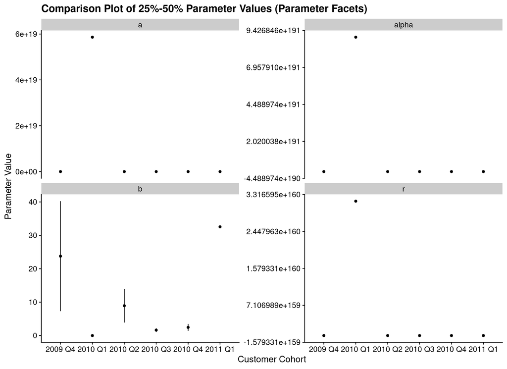

```r
plot_tbl <- qtr_cohort_bgnbd_tbl %>%
  transmute(
    cohort_qtr = cohort_qtr %>% as.character(),
    param_data
    ) %>%
  unnest(param_data)

ggplot(
    plot_tbl,
    aes(x = cohort_qtr, y = mean, ymin = p025, ymax = p075)
    ) +
  geom_errorbar(width = 0) +
  geom_point() +
  expand_limits(y = 0) +
  facet_wrap(vars(parameter), scales = "free_y") +
  labs(
    x = "Customer Cohort",
    y = "Parameter Value",
    title = "Comparison Plot of 25%-50% Parameter Values (Parameter Facets)"
    )
```

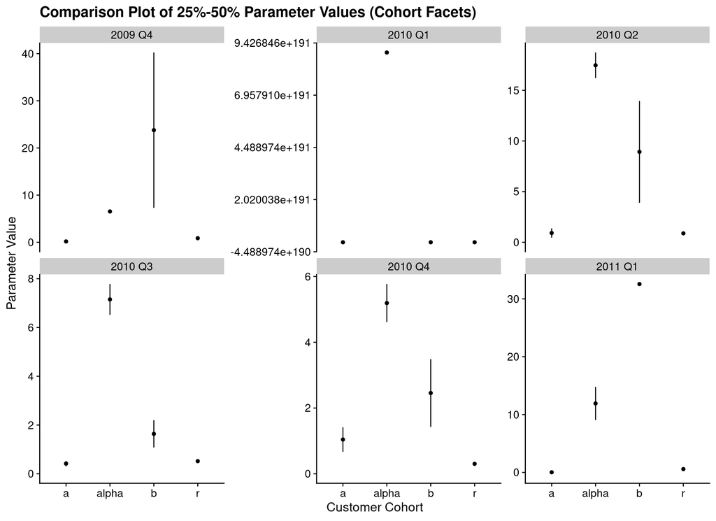

```r
ggplot(
    plot_tbl,
    aes(x = parameter, y = mean, ymin = p025, ymax = p075)
    ) +
  geom_errorbar(width = 0) +
  geom_point() +
  expand_limits(y = 0) +
  facet_wrap(vars(cohort_qtr), scales = "free_y") +
  labs(
    x     = "Customer Cohort",
    y     = "Parameter Value",
    title = "Comparison Plot of 25%-50% Parameter Values (Cohort Facets)"
    )
```

Before we move on to calculating the bootstrap estimates, we save these values into a table as they will be used later.

```r
params_bgnbd_tbl <- params_bgnbd_clvfit %>%
  extract_bgnbd_parameters()

params_bgnbd_tbl %>% glimpse()
```

```
## Rows: 4
## Columns: 4
## $ parameter <chr> "r", "alpha", "a", "b"
## $ mean      <dbl> 0.7187136, 9.8029288, 0.1411387, 4.2801519
## $ p025      <dbl> 0.7043731, 9.5626647, 0.1147364, 3.1206031
## $ p075      <dbl> 0.7330542, 10.0431929, 0.1675410, 5.4397008
```

## 4.2 Constructing Bootstrap Estimates

The nature of the summary statistics used to fit the BG/NBD model means constructing bootstrap models is a little more involved than usual.

```r
construct_split_bgnbd_estimates <- function(tnx_splits, label,
                                            cutoff_date) {

  cache_file <- glue("precompute/{label}_cache.rds") %>% as.character()

  calc_file <- !file_exists(cache_file)

  if(calc_file) {
    tnx_clvdata <- tnx_splits %>%
      analysis() %>%
      group_by(customer_id) %>%
      mutate(
        first_tnx_date = min(invoice_date)
        ) %>%
      mutate(
        cohort_qtr = first_tnx_date %>% as.yearqtr(),
        cohort_ym  = first_tnx_date %>% format("%Y %m"),

        .after = "customer_id"
        ) %>%
      ungroup() %>%
      filter(first_tnx_date <= cutoff_date) %>%
      clvdata(
        date.format      = "%Y-%m-%d",
        time.unit        = "weeks",
        estimation.split = cutoff_date,
        name.id          = "customer_id",
        name.date        = "invoice_date",
        name.price       = "invoice_spend"
        )

    tnx_clvdata %>% write_rds(file = cache_file)
  } else {
    tnx_clvdata <- read_rds(file = cache_file)
  }

  return(tnx_clvdata)
}
```

We now use this function to create a bootstrap distribution of the fitted model parameters. We start by taking bootstrap samples of the transaction data and then built the CLV data from that sample.

```r
n_bootstrap <- 250

bootstrap_clvdata_tbl <- daily_spend_invoice_tbl %>%
  bootstraps(times = n_bootstrap) %>%
  mutate(
    boot_clv = future_map2(
      splits, id,
      construct_split_bgnbd_estimates,
      cutoff_date = training_data_date,

      .options  = furrr_options(globals = TRUE, seed = 421),
      .progress = TRUE
      )
    )

bootstrap_clvdata_tbl %>% glimpse()
```

```
## Rows: 250
## Columns: 3
## $ splits   <list> [<boot_split[36594 x 13399 x 36594 x 4]>], [<boot_split[3659…
## $ id       <chr> "Bootstrap001", "Bootstrap002", "Bootstrap003", "Bootstrap004…
## $ boot_clv <list> <S4 class 'clv.data' [package "CLVTools"] with 7 slots>, <S4…
```

From this set of bootstrapped CLV data we estimate parameters for each of the bootstrap sample.

```r
fit_bgnbd_parameters <- function(clvdata, label) {

  cache_file <- glue("precompute/{label}_bgnbd_fit.rds") %>% as.character()

  calc_file <- !file_exists(cache_file)

  if(calc_file) {
    fit_bgnbd <- bgnbd(
      clvdata,
      start.params.model = c(r = 0.5, alpha = 5, a = 0.1, b = 9.9)
      )

    fit_bgnbd %>% write_rds(file = cache_file)
  } else {
    fit_bgnbd <- read_rds(file = cache_file)
  }

  return(fit_bgnbd)
}
```

```r
bootstrap_bgnbd_tbl <- bootstrap_clvdata_tbl %>%
  mutate(
    bgnbd_fit = future_map2(
      boot_clv, id,
      fit_bgnbd_parameters,

      .options  = furrr_options(globals = TRUE, seed = 422),
      .progress = TRUE
      )
    )

bootstrap_bgnbd_tbl %>% glimpse()
```

```
## Rows: 250
## Columns: 4
## $ splits    <list> [<boot_split[36594 x 13399 x 36594 x 4]>], [<boot_split[365…
## $ id        <chr> "Bootstrap001", "Bootstrap002", "Bootstrap003", "Bootstrap00…
## $ boot_clv  <list> <S4 class 'clv.data' [package "CLVTools"] with 7 slots>, <S…
## $ bgnbd_fit <list> <S4 class 'clv.bgnbd' [package "CLVTools"] with 7 slots>, <…
```

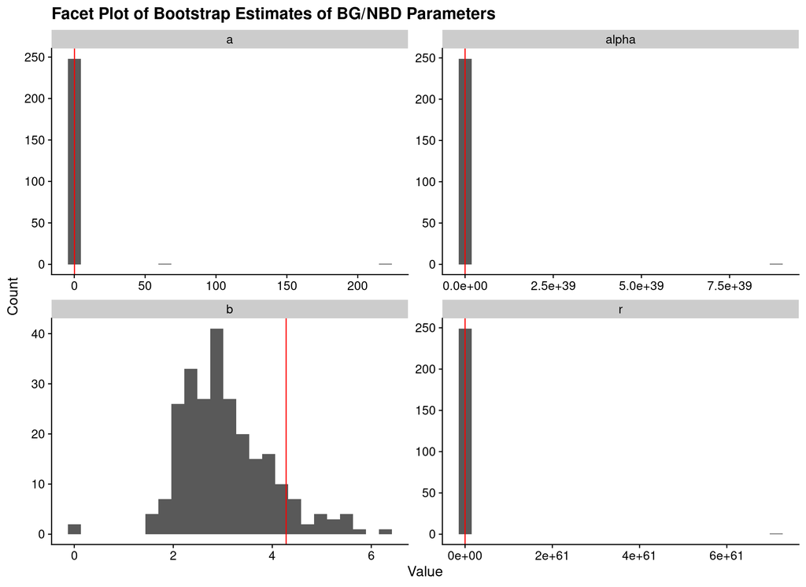

```r
get_coefs <- ~ .x %>%
  coefficients() %>%
  enframe(name = "parameter", value = "value")

bootstrap_fit_params_tbl <- bootstrap_bgnbd_tbl %>%
  mutate(
    param_data = map(bgnbd_fit, get_coefs)
    ) %>%
  select(id, param_data) %>%
  unnest(param_data) %>%
  inner_join(params_bgnbd_tbl, by = "parameter")

ggplot(bootstrap_fit_params_tbl) +
  geom_histogram(aes(x = value), bins = 25) +
  geom_vline(aes(xintercept = mean), colour = "red") +
  expand_limits(y = 0) +
  facet_wrap(vars(parameter), scales = "free") +
  labs(
    x = "Value",
    y = "Count",
    title = "Facet Plot of Bootstrap Estimates of BG/NBD Parameters"
    )
```